# BR CoopScore

## 2.4 All possible variables in PCA

We cannot run with all coalitions, as we need more units (19) than variables (25). 10 coalitions show NA results, so we can disconsider them. So we run now PCA with coop for all coalitions but COMIFAC, CaribbeanC, CentralAm, CentralG11, EITs, G9, Mountain, OPEC, SAfricaDC, Visegrad

```r
df_full <- df %>%
  select(-c(weighted_score, weighted_score_avg, coop_score, coop_score_2)) %>% #calcular c/ coop_avg
  # filter(year == 1995) %>% # separar o ano (se nao quiser rodar PCA p/ todos dados juntos)
  pivot_wider(names_from = "grouping", values_from = "coop_avg") %>%
  select(-c(year, country)) %>% # remover as colunas não numéricas
  scale() %>% as_tibble() %>%
  select(-c(COMIFAC, CaribbeanC, CentralAm, CentralG11, EITs, G9, Mountain, OPEC, SAfricaDC, Visegrad))

pca_full <- princomp(df_full, fix_sign = FALSE)

summary(pca_full, loadings = T, cutoff = 0.3)
```

```
## Importance of components:
##                           Comp.1    Comp.2    Comp.3     Comp.4     Comp.5
## Standard deviation     2.7080882 1.7342742 1.2573840 0.86356108 0.71762066
## Proportion of Variance 0.5160781 0.2116535 0.1112566 0.05247784 0.03623929
## Cumulative Proportion  0.5160781 0.7277316 0.8389882 0.89146602 0.92770531
##                            Comp.6     Comp.7      Comp.8      Comp.9
## Standard deviation     0.63048449 0.47842517 0.359840267 0.349737507
## Proportion of Variance 0.02797297 0.01610712 0.009111909 0.008607445
## Cumulative Proportion  0.95567829 0.97178540 0.980897314 0.989504759
##                            Comp.10     Comp.11     Comp.12      Comp.13
## Standard deviation     0.255404369 0.220568061 0.145378521 0.1087153621
## Proportion of Variance 0.004590357 0.003423537 0.001487272 0.0008317095
## Cumulative Proportion  0.994095116 0.997518653 0.999005925 0.9998376345
##                            Comp.14      Comp.15
## Standard deviation     0.047429318 7.599975e-03
## Proportion of Variance 0.000158301 4.064565e-06
## Cumulative Proportion  0.999995935 1.000000e+00
##
## Loadings:
##          Comp.1 Comp.2 Comp.3 Comp.4 Comp.5 Comp.6 Comp.7 Comp.8 Comp.9 Comp.10
## AILAC    -0.342
## ALBA     -0.311
## AOSIS            0.372 -0.337                              0.484
## AfricanG                       0.678        -0.456
## ArabG                   0.301                0.639        -0.322
## BASIC                                              -0.446         0.394  0.496
## CfRN                                                0.393               -0.456
## CongoB   -0.347
## EU               0.368                              0.392         0.627
## EIG                                                       -0.540 -0.449
## G77             -0.487         0.384
## LDCs                                               -0.572               -0.531
## LMDC            -0.314               -0.812
## SICA     -0.347                                            0.352
## Umbrella                0.710               -0.316
##          Comp.11 Comp.12 Comp.13 Comp.14 Comp.15
## AILAC                            -0.510   0.645
## ALBA             -0.630   0.492
## AOSIS                             0.328
## AfricanG  0.349
## ArabG     0.410
## BASIC
## CfRN              0.518
## CongoB                           -0.448  -0.740
## EU                                0.326
## EIG      -0.413
## G77      -0.534                   0.344
## LDCs
## LMDC
## SICA             -0.378  -0.740
## Umbrella                          0.386
```

### 2.4.1 Diagnostics

Como no caso do expanded, interpretação da dimensão 1 está pouco clara e a dimensão 2 parece ser algo como Norte x Sul.

```r
get_eigenvalue(pca_full)
```

|  | eigenvalue | variance.percent | cumulative.variance.percent |
| --- | --- | --- | --- |
| Dim.1 | 7.333742e+00 | 5.160781e+01 | 51.60781 |
| Dim.2 | 3.007707e+00 | 2.116535e+01 | 72.77316 |
| Dim.3 | 1.581015e+00 | 1.112566e+01 | 83.89882 |
| Dim.4 | 7.457377e-01 | 5.247784e+00 | 89.14660 |
| Dim.5 | 5.149794e-01 | 3.623929e+00 | 92.77053 |
| Dim.6 | 3.975107e-01 | 2.797297e+00 | 95.56783 |
| Dim.7 | 2.288906e-01 | 1.610712e+00 | 97.17854 |
| Dim.8 | 1.294850e-01 | 9.111909e-01 | 98.08973 |
| Dim.9 | 1.223163e-01 | 8.607445e-01 | 98.95048 |
| Dim.10 | 6.523139e-02 | 4.590357e-01 | 99.40951 |

[output cut: 5 more lines]

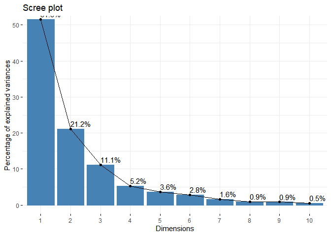

```r
fviz_eig(pca_full, addlabels = T, ylim = c(0, 50))
```

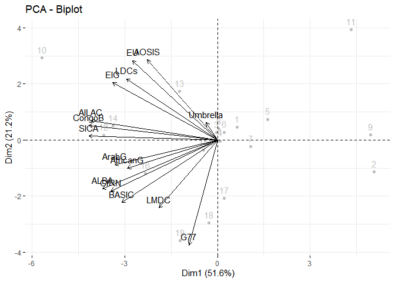

```r
fviz_pca_biplot(pca_full, repel = F, col.var = "black", col.ind = "gray")
```

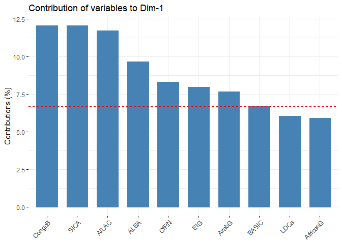

```r
fviz_contrib(pca_full, choice = "var", axes = 1, top = 10)
```

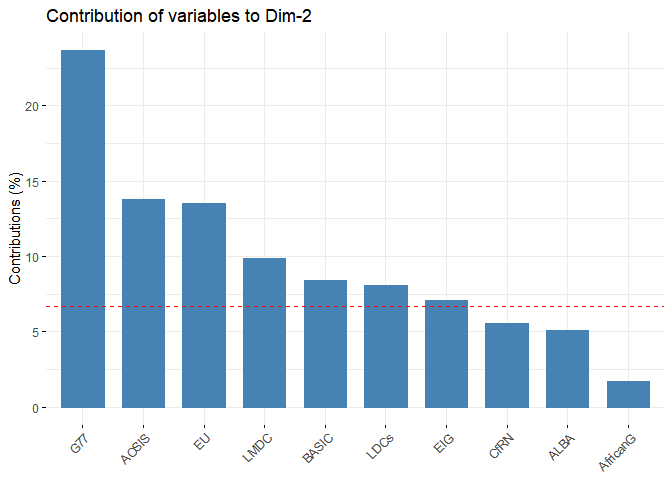

```r
fviz_contrib(pca_full, choice = "var", axes = 2, top = 10)
```

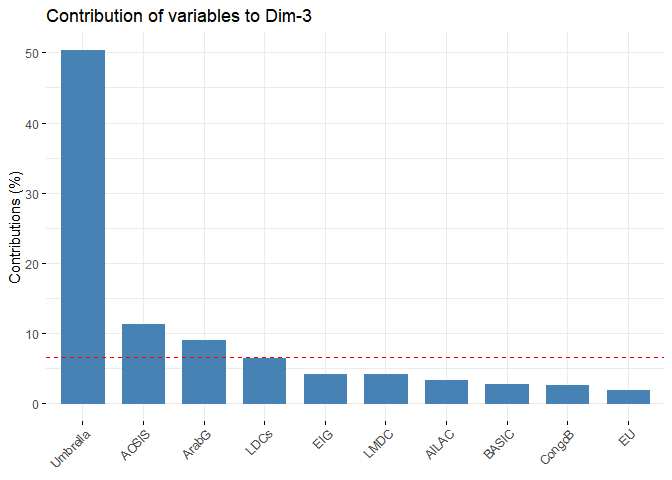

```r
fviz_contrib(pca_full, choice = "var", axes = 3, top = 10)
```